# Week13_Friday slides

## Week 13 Friday

Friday, Nov 22

**Announcements**

- A09 Assigned: Due Monday, Dec 2
- A10 Assigned: Due Friday, Dec 13

**Goals**

- Introduction to probabilistic occupancy: Part 2
- Work time

## Last Time

[figure not shown]

### This is an equation for convolution!

$$Bel(j)_k = \sum_{i=0}^{p-1} H(i)\cdot Bel\left(j+i-\frac{p-1}{2}\right)_{k-1}$$

our PDF $H$ with length $p$ is a "kernel" that we convolve over the prior belief to obtain an updated belief that accounts for the additional uncertainty in our latest prediction. As time goes on, we get more and more uncertain.

**How do we fix this? Using measurements to reduce uncertainty!**

## Last Time:

- Given a PDF of size $p$, $H = \begin{bmatrix} H_0 & H_1 & \ldots & H_{p-1} \end{bmatrix}$
- Given a Belief grid of size $m$, spanning $d$ meters: $Bel = \begin{bmatrix} Bel_0 & Bel_1 & \ldots & Bel_{m-1} \end{bmatrix}$
- We can predict how uncertainty progresses due to model uncertainty at each timestep by convolving $H$ with $Bel$

## As an algorithm (Python pseudocode):

**for all timesteps k do:**

- $\hat{x}_k = f(\hat{x}_{k-1},u_{k-1})\leftarrow$ update model prediction
- $\hat{j}_{k} = int\left(\frac{m}{d}\left(\hat{x}_k -\frac{d}{2m} \right) \right)\leftarrow$ update cell estimate
- $\Delta j = \hat{j}_k-\hat{j}_{k-1}\leftarrow$ update shift
- $Bel_{old} = Bel \leftarrow$ copy belief from prior timestep
- for b in range(max(0,$\Delta j$),min(m+$\Delta j$,m)):
  - $Bel(j+\Delta j) = Bel_{old}(j)\leftarrow$ shift belief
- for r in range(0,m):
  - $Bel[r]_{k}= \sum_{i=0}^{p-1} H[r]\cdot Bel\left[r+i-\frac{p-1}{2}\right]\leftarrow$ update belief
- $\hat{j}_k = argmax(Bel)\leftarrow$ most likely estimate
- $\hat{x}_k = \hat{j}_k\frac{d}{m} + \frac{d}{2m}\leftarrow$ convert back to an estimate in true units

.

.

.

.

.

## Implemented as actual Python code:

```
H = [0.3 0.4 0.3]
```

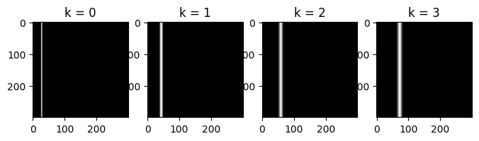

## How do measurements influence our belief?

**They *should* improve it! By how much? We need some more tools.. but what we know is that:**

Given a measurement $z_k$ of where we are: \begin{equation} P(j | z_k,Bel_{old}) \end{equation} is the probability of being in a cell $j$ given the measurement we got, and our prior belief. This should lead to a *more certain* belief than propagating belief using our model alone.

## [Conditional Probability: Demo](https://setosa.io/conditional/)

## Conditional Probability

\begin{equation} \begin{aligned} P(x,y) &= P(x|y)\cdot P(y) \\ P(y,x) &= P(y|x)\cdot P(x) \end{aligned} \end{equation}

Also, by definition, $P(x,y)=P(y,x)$ because it's the probability of both $x$ and $y$ occurring.

### The Law of Total Probability: "We must be somewhere"

\begin{equation} \begin{aligned} \sum_y P(y) &= 1\\ \rightarrow P(x) &= \sum_y P(x,y) \\ \rightarrow P(x) &= \sum_y P(x|y)P(y)\\ \end{aligned} \end{equation}

### Rearranging the law of conditional probability gives us something special:

Because $P(x,y)=P(y,x)$, \begin{equation} \begin{aligned} P(y|x)\cdot P(x) &= P(x|y)\cdot P(y) \\ \rightarrow P(x|y) &= \frac{P(y|x)P(x)}{P(y)} \end{aligned} \end{equation} This is called ["Bayes's rule"](https://en.wikipedia.org/wiki/Bayes%27_theorem). Implementing it usually requires using the law of total probabilty to determine certain "pieces," such as $P(y)$. But Bayes's rule tells us about how to modify our "prior belief" $P(x)$ based on new information $y$.

## What's next?

For us, we will use Bayes's rule to condition the propagated probability of being in cell $j$ at time $k$ using a *measurement* $z_k$.

- "event x" is our probability of being in cell j *before* our measurement
- "event y" is receiving a measurement $z_k$
- $P(x|y)$ is our *updated* probability of being in cell j given our measurement $z_k$.

So think about how we would apply $P(x|y) = \frac{P(y|x)P(x)}{P(y)}$. How would we get, for example, $P(y)$, or the *total* probability of getting that measurement $z_k$?